# Analysis of Credit Card Customer Behavior and Attrition

## 4. To find the retention rate of customers over a period using Kaplan Meier’s Survival Analysis and check if there is a difference in the duration between Males and Females?

```r
df1=df

df1$Attrition_Flag <- as.factor(df1$Attrition_Flag)

df1$event = ifelse(df1$Attrition_Flag == "Attrited Customer", 1, 0)

surv_object = Surv(time= df1$Months_on_book, event= df1$event)

km_fit = survfit(surv_object ~ df1$Gender, data = df)
summary(km_fit)
```

```
## Call: survfit(formula = surv_object ~ df1$Gender, data = df)
##
##                 df1$Gender=F
##  time n.risk n.event survival  std.err lower 95% CI upper 95% CI
##    13   5358       4    0.999 0.000373        0.999        1.000
##    15   5314       6    0.998 0.000592        0.997        0.999
##    16   5295       2    0.998 0.000649        0.996        0.999
##    17   5280       1    0.998 0.000676        0.996        0.999
##    18   5262       6    0.996 0.000819        0.995        0.998
##    19   5231       2    0.996 0.000862        0.994        0.998
##    20   5203       7    0.995 0.000999        0.993        0.997
##    21   5162       6    0.994 0.001104        0.991        0.996
##    22   5121      10    0.992 0.001260        0.989        0.994
##    23   5066       7    0.990 0.001361        0.988        0.993
##    24   5003      18    0.987 0.001594        0.984        0.990
```

[output cut: 79 more lines]

### Log rank test to determine statistical significance of results

```r
surv_test = survdiff(surv_object ~ df1$Gender, data = df1)

print(surv_test)
```

```
## Call:
## survdiff(formula = surv_object ~ df1$Gender, data = df1)
##
##                 N Observed Expected (O-E)^2/E (O-E)^2/V
## df1$Gender=F 5358      930      863      5.17      11.3
## df1$Gender=M 4769      697      764      5.84      11.3
##
##  Chisq= 11.3  on 1 degrees of freedom, p= 8e-04
```

P value 8e-04 < alpha Hence, we can conclude that there is a statistically significant difference between the retention rates of Male and Female, indicating gender is a significant factor in predicting customer survival time

###Interpretation

Therefore, at month 56, the chances of Females to still continue with the bank is 38.7% whereas for males is 48.9%.

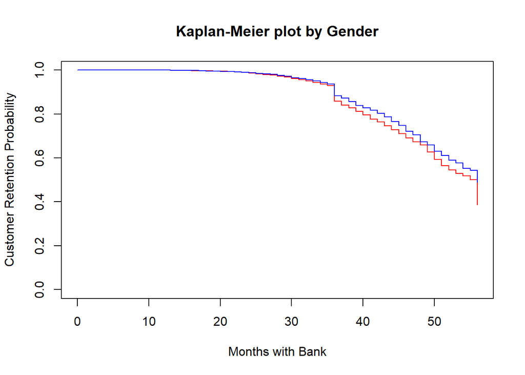

```r
plot(km_fit,
     col = c("red", "blue"),
     main = "Kaplan-Meier plot by Gender",
     xlab = "Months with Bank",
     ylab = "Customer Retention Probability" ,
)
```

###Interpretation:

Blue line here represents Males whereas Red line here represents Females.

From the graph, we can also identify that there is a drop in probability of customers staying with the company at month 36 (completion of 3 years).

## 5. To identify the impact of key variables on the odds of customer churn using a Logistic Regression framework and create a Model to predict if a customer has been lost by the bank

```r
n=nrow(df1)

train_index=sample(1:n, size=0.7*n)

train_data = df1[train_index, ]
test_data = df1[-train_index, ]

colnames(train_data)
```

```
##  [1] "CLIENTNUM"
##  [2] "Attrition_Flag"
##  [3] "Customer_Age"
##  [4] "Gender"
##  [5] "Dependent_count"
##  [6] "Education_Level"
##  [7] "Marital_Status"
##  [8] "Income_Category"
##  [9] "Card_Category"
## [10] "Months_on_book"
## [11] "Total_Relationship_Count"
## [12] "Months_Inactive_12_mon"
## [13] "Contacts_Count_12_mon"
## [14] "Credit_Limit"
## [15] "Total_Revolving_Bal"
## [16] "Avg_Open_To_Buy"
## [17] "Total_Amt_Chng_Q4_Q1"
## [18] "Total_Trans_Amt"
## [19] "Total_Trans_Ct"
## [20] "Total_Ct_Chng_Q4_Q1"
## [21] "Avg_Utilization_Ratio"
## [22] "Naive_Bayes_Classifier_Attrition_Flag_Card_Category_Contacts_Count_12_mon_Dependent_count_Education_Level_Months_Inactive_12_mon_1"
## [23] "Naive_Bayes_Classifier_Attrition_Flag_Card_Category_Contacts_Count_12_mon_Dependent_count_Education_Level_Months_Inactive_12_mon_2"
## [24] "event"
```

```r
lr_model = glm(event ~ Total_Trans_Ct + Months_Inactive_12_mon + Total_Revolving_Bal + Total_Relationship_Count , data = train_data,
            family = binomial)

stargazer(lr_model, type = "text")
```

```
##
## ====================================================
##                              Dependent variable:
##                          ---------------------------
##                                     event
## ----------------------------------------------------
## Total_Trans_Ct                    -0.067***
##                                    (0.002)
##
## Months_Inactive_12_mon            0.443***
##                                    (0.039)
##
## Total_Revolving_Bal               -0.001***
##                                   (0.00005)
##
## Total_Relationship_Count          -0.555***
##                                    (0.029)
##
## Constant                          3.935***
##                                    (0.207)
##
## ----------------------------------------------------
## Observations                        7,088
## Log Likelihood                   -2,065.198
## Akaike Inf. Crit.                 4,140.395
## ====================================================
## Note:                    *p<0.1; **p<0.05; ***p<0.01
```

Calculation of odds, for example, For Months inactive, odds per 1 unit increase = e^0.443 times.

```r
test_data$prob = predict(lr_model, newdata = test_data, type = "response")

test_data$pred_class = ifelse(test_data$prob>0.5,1,0)

cm=table(Actuals = test_data$event, Predicted = test_data$pred_class)
cm
```

```
##        Predicted
## Actuals    0    1
##       0 2475   79
##       1  267  218
```

```r
accuracy <- mean(test_data$event == test_data$pred_class)
cat("Accuracy:", round(accuracy,3), "\n")
```

```
## Accuracy: 0.886
```

This model has an accuracy of 88.6%

## 6. To determine the optimal linear combination of customer attributes that maximizes the separation between loyal and churning customers and to create a model to predict if a customer would continue to exist with the company using linear discriminant analysis.

```r
df_selected <- df[, c("Attrition_Flag",
                      "Total_Trans_Ct",
                      "Months_Inactive_12_mon",
                      "Total_Revolving_Bal",
                      "Total_Relationship_Count",
                      "Contacts_Count_12_mon",
                      "Customer_Age")]

# Converting the target to a Factor (Category)
df_selected$Attrition_Flag <- as.factor(df_selected$Attrition_Flag)

sample_index <- sample(1:nrow(df_selected), 0.7 * nrow(df_selected))

train_data <- df_selected[sample_index, ]
test_data  <- df_selected[-sample_index, ]


# Scaling the numeric columns so coefficients are comparable.

numeric_cols <- c("Total_Trans_Ct", "Months_Inactive_12_mon",
                  "Total_Revolving_Bal", "Total_Relationship_Count",
                  "Contacts_Count_12_mon", "Customer_Age")


train_data_scaled <- train_data
train_data_scaled[, numeric_cols] <- scale(train_data[, numeric_cols])

#Scaling the Test Data
# scale the test data using the MEAN and SD from the TRAINING data.

train_scales <- scale(train_data[, numeric_cols])
test_data_scaled <- test_data
test_data_scaled[, numeric_cols] <- scale(test_data[, numeric_cols],
                                          center = attr(train_scales, "scaled:center"),
                                          scale = attr(train_scales, "scaled:scale"))

lda_model = lda(Attrition_Flag ~ ., data = train_data_scaled)

print(lda_model)
```

```
## Call:
## lda(Attrition_Flag ~ ., data = train_data_scaled)
##
## Prior probabilities of groups:
## Attrited Customer Existing Customer
##         0.1612585         0.8387415
##
## Group means:
##                   Total_Trans_Ct Months_Inactive_12_mon Total_Revolving_Bal
## Attrited Customer     -0.8354030             0.35190263          -0.5835820
## Existing Customer      0.1606166            -0.06765765           0.1122009
##                   Total_Relationship_Count Contacts_Count_12_mon Customer_Age
## Attrited Customer              -0.35629193            0.46876858   0.07748008
## Existing Customer               0.06850154           -0.09012657  -0.01489651
##
## Coefficients of linear discriminants:
##                                   LD1
## Total_Trans_Ct            0.856902615
## Months_Inactive_12_mon   -0.273338406
## Total_Revolving_Bal       0.484264752
## Total_Relationship_Count  0.560146593
## Contacts_Count_12_mon    -0.314960461
## Customer_Age              0.002940107
```

###Interpretation:

-From the coefficients of linear discriminants, we can conclude that total transaction count is the strongest driver in the model, followed by total relationship counts (number of products with the company) and total revolving balance. These have positive coefficients, meaning the higher these metrics are, the more likely the customer is to continue with the bank

-Contacts count and inactive months have negative coefficients which mean the more the customer contacts the bank and more inactive the customer is, more likely is the customer to leave the bank

```r
lda_predictions = predict(lda_model, newdata = test_data_scaled)

cm_lda = table(Predicted = lda_predictions$class, Actual = test_data_scaled$Attrition_Flag)
print(cm_lda)
```

```
##                    Actual
## Predicted           Attrited Customer Existing Customer
##   Attrited Customer               228                75
##   Existing Customer               256              2480
```

The model is good at predicting if a customer will continue to exist with the company, however this model can give incorrect predictions if it predicts Attried customer.

```r
test_data_scaled$pred_class = lda_predictions$class
accuracy = mean(test_data_scaled$Attrition_Flag == test_data_scaled$pred_class)
cat("Accuracy:", round(accuracy,3), "\n")
```

```
## Accuracy: 0.891
```

This model has an accuracy of 89.1%